# DSP Project Report

Comparison of Longe Term No-TIll and Conventional Till in Conover Soils

Generated by the DSHub

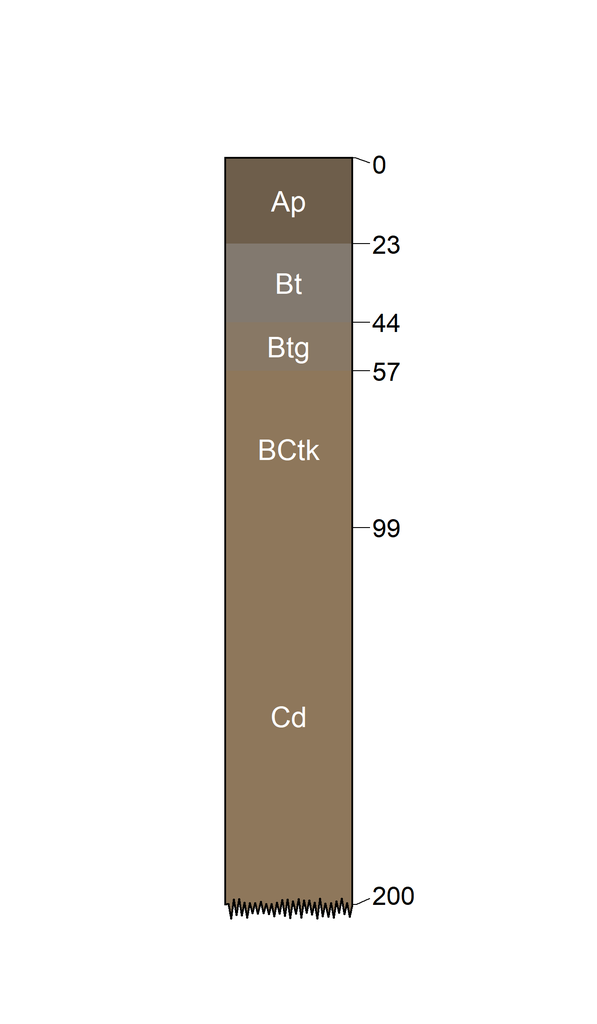

The Conover consists of fine-loamy, mixed, active, mesic Aquic Hapludalfs. Plot depths in cm.

| Project Name | Project ID | MLRA | State | County/Parish |
| --- | --- | --- | --- | --- |
| DSP MI98 2020 Comparison of Long Term No-Till and Conventional Till in Conover Soil Series | 2020GRR014 | 98: Southern Michigan and Northern Indiana Drift Plains, 99: Erie-Huron Lake Plain | Michigan (MI) | Clinton (MI037) , Eaton (MI045) , Gratiot (MI057) , Ingham (MI065) , Shiawassee (MI155) |

## Objectives and Project Background

The purpose of the 2020GRR014 DSP project was to evaluate DSPs for soils associated with the Conover series on multiple land uses including soil health management systems and generate a report of the mean and range for soil health indicators by soil and land management system to be used by the MI State Soil Scientist to make conservation recommendations.

[interactive chart not shown]

Figure 1: The Conover series extent and DSP site locations. The size of each point on the amp corresponds to the depth of soil sampled there.

This report summarizes any data currently available for the 2020GRR014 project to determine; (1) how soil health indicators different between land uses, and (2) if these observations are representative of the full extent of the soil component and ecological site.

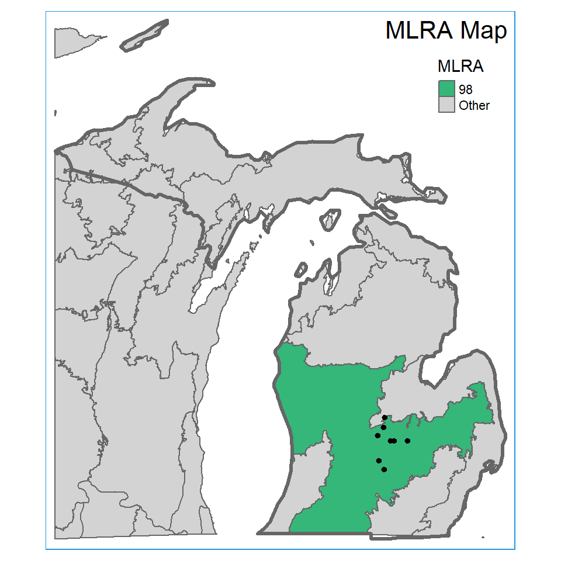

Most the study sites occur in Major Land Resource Area (MLRA) 98: Southern Michigan and Northern Indiana Drift Plains. The area is a broad glaciated plain that is deeply mantled by till in the north and outwash to the south. Much of the area is nearly level to gently rolling much of which is cultivated.

## Study Area

### Conover Soils

The Conover series consists of very deep, somewhat poorly drained soils that are moderately deep or deep to dense till. These soils formed in loamy till on moraines and till plains. Slope ranges from 0 to 6 percent but is dominantly 0 to 4 percent. Mean annual precipitation is about 810 mm and the mean annual temperature is about 9 degrees C. Conover soils have loam, silt loam, or sandy loam surface textures with typical pH values ranging from 5.6 to 7.3 and soil organic matter ranging from 2 to 5 percent.

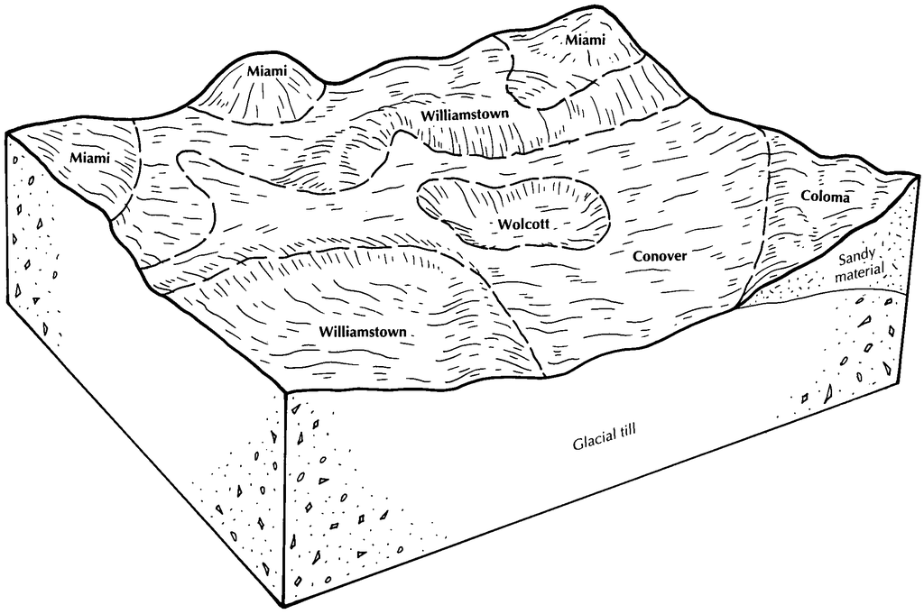

Figure 2: Typical pattern of soils and parent material in the Miami-Williamston-Conover association (Soil Survey of Hillsdale County, Michigan; 1997)

### Land use

Corn, beans, small grain, and legume-grass hay are the principal crops. Cropland soil Health managment systems in this area include conservation practices such as no-till/reduced till, cover crops, conservation crop rotation, nutrient and pest management, and in some places livestock integration.

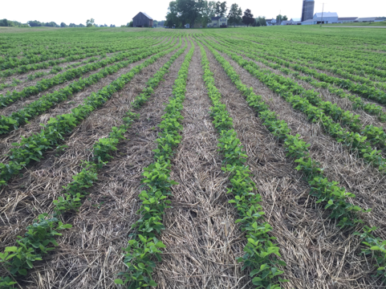

Soybeans that were no-till planted into a stand of cereal rye. Cereal rye, also known as winter rye is a common cover crop in cool climates. The cereal rye is often planted after fall harvest of crops such as corn to scavenge nitrogen, protect the soil from erosion, and suppress weeds.

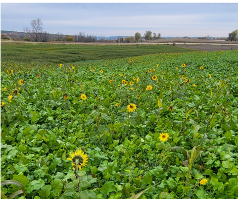

Multi-species cover crop planted following the late summer harvest of wheat. The cover crop provides an opportunity for in season manure applications and will winter kill. The following spring the producer can no-till plant corn and gain a nitrogen credit from the decayed cover crop.

### Ecological Dynamics

Native vegetation is mixed hardwoods, predominantly American beech, sugar maple, basswood, northern red oak. The majority of study sites were correlated to the F098AX011MI Moist Loamy Drift Plains Ecological Site Description. A few sites sampled were correlated to F099XY007MI Lake Plain Flat which is considered as a similar ecological site.

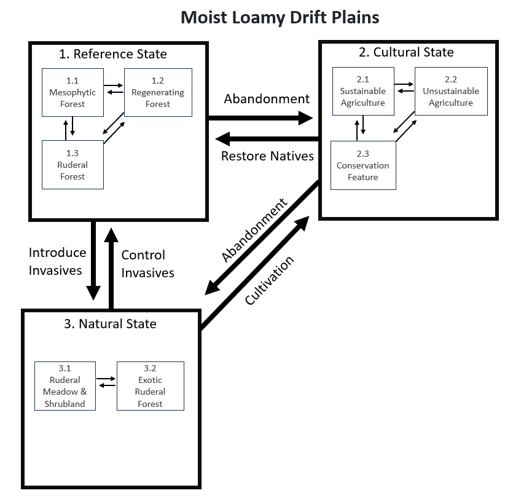

Figure 3: State and Transition model for the F098AX011MI ecological site. State and transition models (STMs) describe changes in plant communities and associated dynamic soil properties that can occur on an ecological site.

### Study Methods

At each site location a central soil pit was described and sampled by horizon to 200 cm or restrictive feature. Two satellite pits were also described and sampled to 50 cm to capture variability within the site.

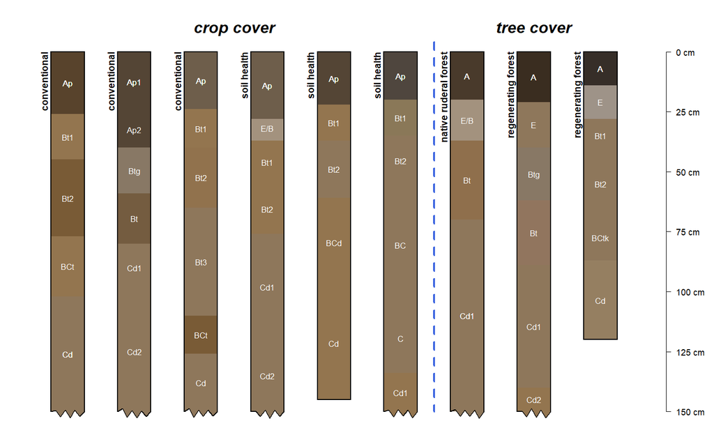

Figure 4: Central pit location soil profiles described and sampled at each site location. The sites in this study included 3 conventional row crop farms, 3 soil health row crop farms, and 3 forested sites (9 sites total).

## Results

#### Soil Color

Soil Color is often an indicator of soil organic matter content. Darker hues observed in the soil often indicate more organic matter whereas lighter colors typically indicate less organic matter is present in the soil. Soil color values that are 3/2 or darker support organic matter depletion is not a resource concern, but the observing color alone cannot precisely estimate organic matter percent.

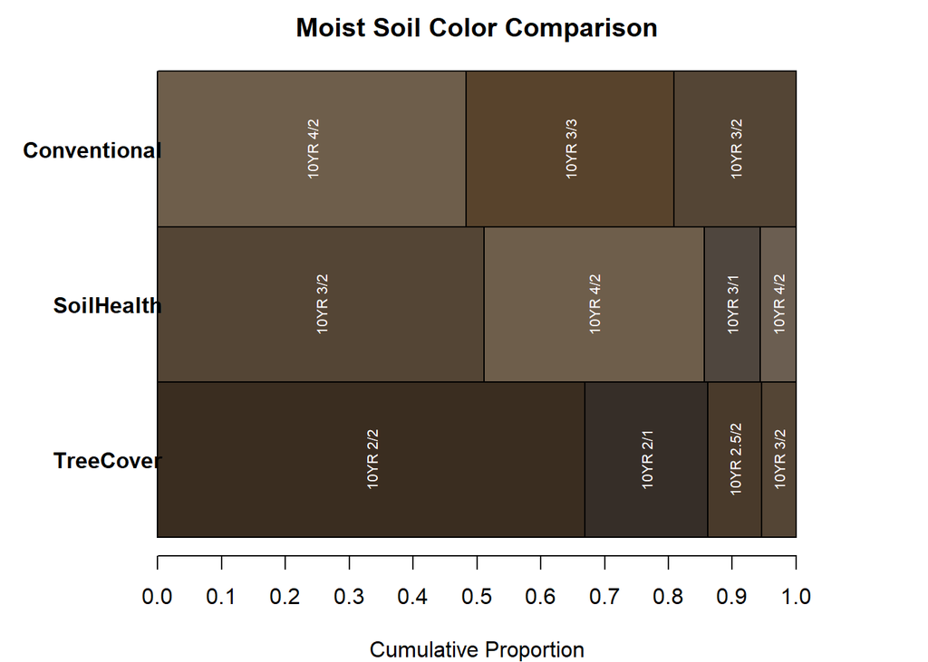

Figure 5: Proportion of colors observed in the top horizon of each soil profile described in the study. Note the darker colors observed with sites that have tree cover and the larger proportion of soils with hues and chromas less than or equal to 3.

#### Penetrometer Resistance

Soil compaction was estimated using a Dickey-John 30” Soil Compaction Tester (Mfr. Model #155850003AS1). Measurements (units in PSI) were taken in four locations around each pedon. Maximum resistance is measured for 0-15 cm (surface)and 15-46 cm (subsurface) depths. Values > 150 PSI in the surface and > 300 PSI in the subsurface are indicative of compaction.

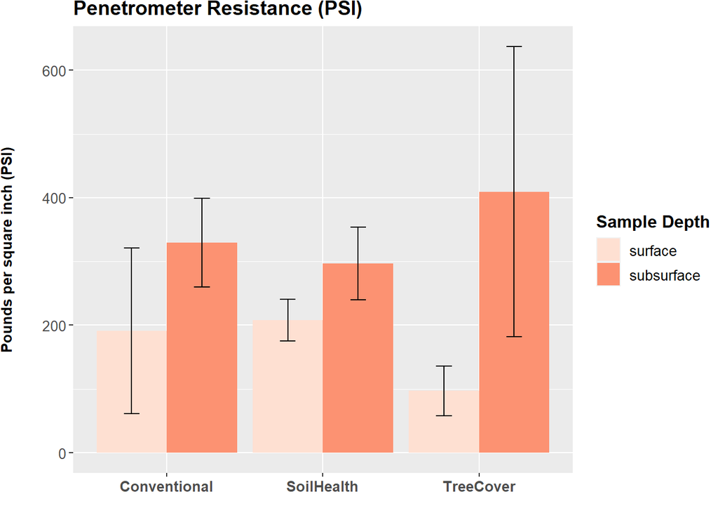

Figure 6: Penetrometer resistance. No significant differences were observed between treatments except tree cover was observed to have lower penetration resistance in the surface when compared to the soil health management systems.

#### Soil Structure Kind

Soil structure is also an indicator of compaction. Soils with platy or massive structure often prohibit root growth and water movement. Soils with granular structure have more voids allowing root and water movement. Subangular blocky structure is a common structure kind in the croplands in this region and is typically does not support the presence of compaction .

| Treatment | Primary Structure in Surface Horizon |
| --- | --- |
| Conventional | Subangular Blocky |
| Soil Health | Subangular Blocky |
| Tree Cover | Granular |

#### Saturated Hydraulic Conductivity (Ksat)

Saturated hydraulic conductivity (Ksat) is a measurement of how fast water moves through the soil when completely saturated. Water conductivity is measured under saturated conditions to account for the influence of soil moisture on water transmission and obtain comparable values between sites. An Amoozemeter was used to measure Ksat but only at a select few study sites.

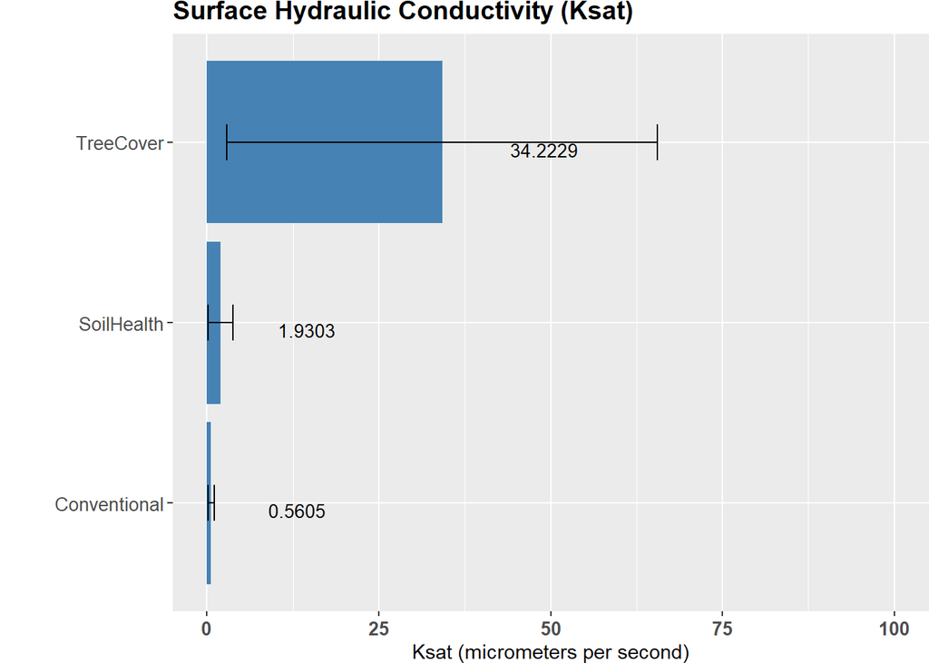

Figure 7: Saturated Hydraulic Conductivity. Values are in micrometers per second. Lower Ksat values observed in the conventionally farmed site indicate tillage induced compaction may be limiting water flow, but due to the limited number of measurements it is uncertain if there is a significant difference between treatments. n = 5 Treecover (1 site), Conventional (2 sites), Soil Health (2 sites).

#### Soil pH

Soil pH is a dynamic soil property that is influenced by management, but often is not used as an indicator of soil health.

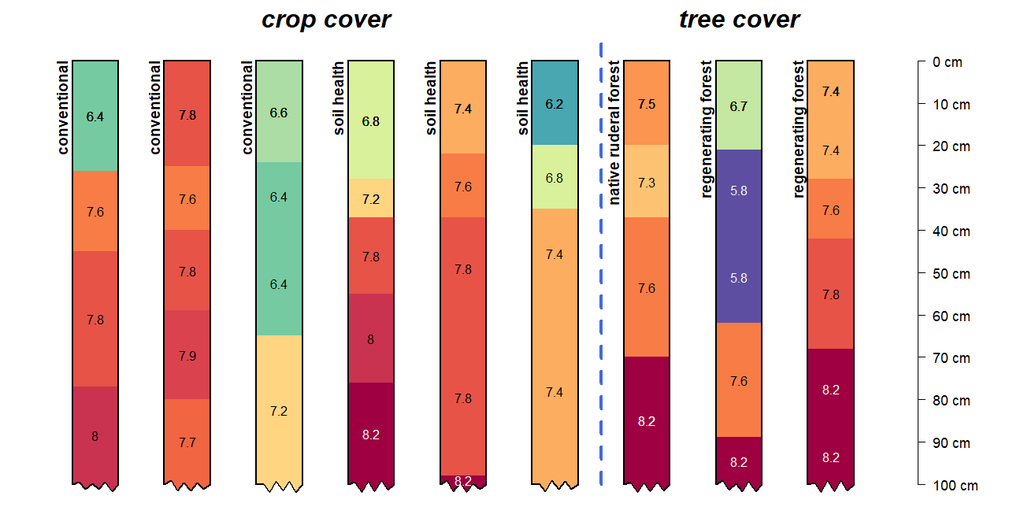

Figure 8: Soil pH profile plot. pH was measured for each soil horizon. Typical soil pH in Conover surface horizons ranges from 5.6 to 7.3.

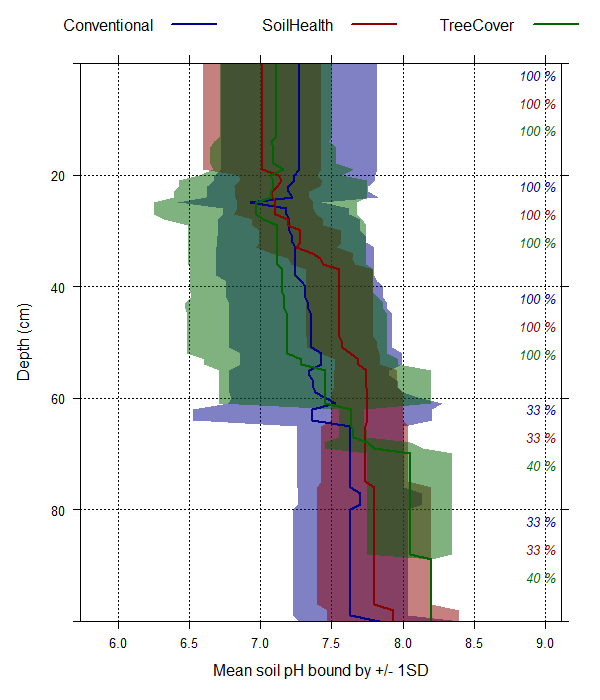

Figure 9: Soil pH comparison with depth.

No significant difference was observed between the pH values observed between the different treatments investigated in this project.

## Conclusion

This project investigated DSPs on Conover soils by comparing sites with tree cover with those in agricultural. Since only a few sites were sampled for each treatment, caution should be taken when drawing conclusions from the results.

There appears to be some differences in dynamic soil properties between the three treatments; tree cover, soil health, and conventional. In their natural state, which occurs following agrigultural abandonment, Conover soils exhibited darker colors, more granular structure, and faster water movement. These observations are the result of more above and below ground vegetation in a hardwood forest setting, and thus more root growth and organic matter accumulation in the soil. Only slight differences were observed between the conventional and soil health management systems. These different community phases do have dissimilar management practices, but provide the similar ecological function, which is why they exist within the same ecological state. In this project, soil health systems did have slightly darker colors and faster water movement, but there is not enough data to quality a difference or be certain the differences were not due to chance.

Laboratory data collected for this study is still be analyzed by the Kellogg Soil Survey Laboratory and may be added to this report in the future.